# Лабораторная работа № 12

Настройки сети в Linux

Павличенко Родион Андреевич

1132246838@pfur.ru

Российский университет дружбы народов

2025-06-09

# Информация

## Докладчик

- Павличенко Родион Андреевич
- Cтудент
- Группа НПИбд-02-24
- Российский университет дружбы народов им. П. Лумумбы
- 1132246838@pfur.ru

# Выполнение лабораторной работы

## Получили полномочия администратора. Вывели на экран информацию о существующих сетевых подключениях, а также статистику о количестве отправленных пакетов и связанных с ними сообщениях об ошибках.

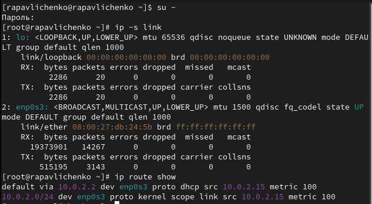

Работа с сетевыми подключениями

## Вывели на экран информацию о текущих назначениях адресов для сетевых интерфейсов на устройстве. Для отправки четырёх пакетов на IP-адрес 8.8.8.8 ввели ping -c 4 8.8.8.8

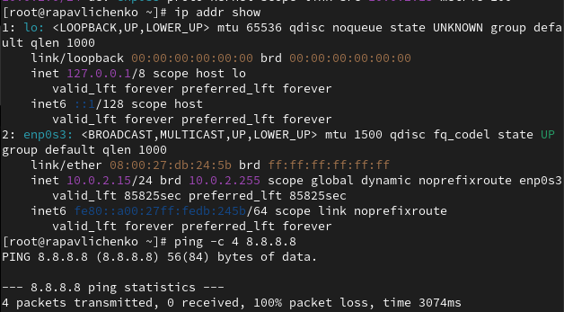

Адреса для сетевых интерфейсов

## Добавили дополнительный адрес к нашему интерфейсу. Проверили, что адрес добавился командой ip addr show. Сравнили вывод информации от утилиты ip и от команды ifconfig. Вывели на экран список всех прослушиваемых системой портов UDP и TCP.

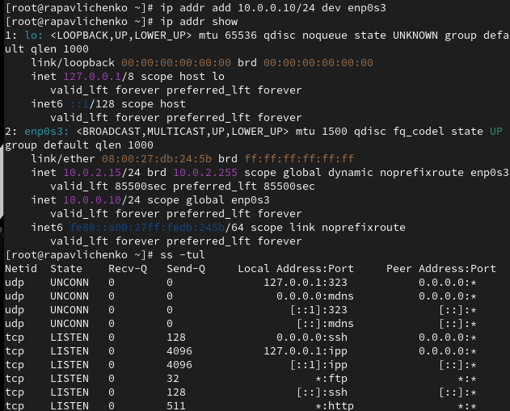

Добавление дополнительного адреса к нашему интерфейсу

## Получили полномочия администратора. Вывели на экран информацию о текущих соединениях. Добавили Ethernet-соединение с именем dhcp к интерфейсу. Добавили к этому же интерфейсу Ethernet-соединение с именем static, статическим IPv4-адресом адаптера и статическим адресом шлюза.

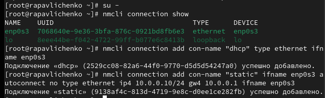

Добавление соединений

## Вывели информацию о текущих соединениях. Переключились на статическое соединение. Проверили успешность переключения при помощи nmcli connection show и ip addr

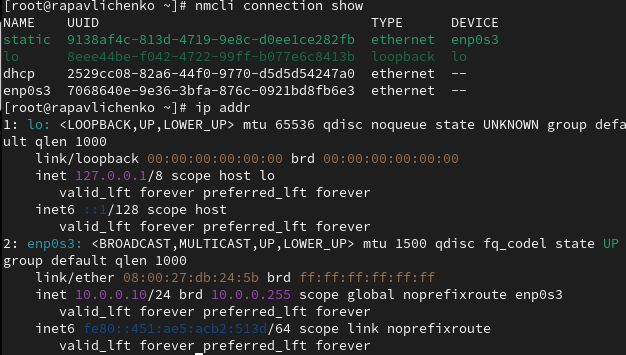

Вывод информации о текущих соединениях

## Вернулись к соединению dhcp. Проверили успешность переключения при помощи nmcli connection show и ip addr

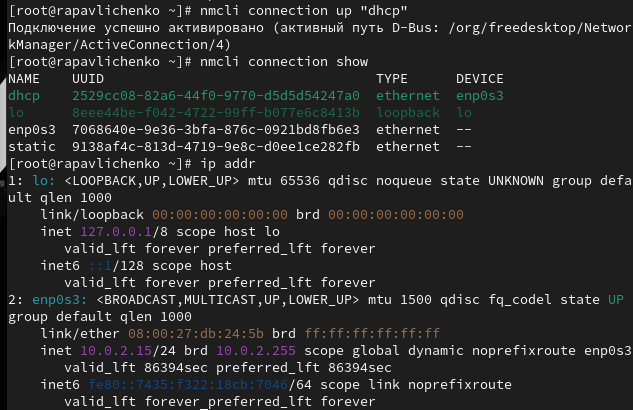

Возврат к соединению dhcp

## Отключили автоподключение статического соединения. Добавили DNS-сервер в статическое соединение. Обратили внимание, что при добавлении сетевого подключения используется ip4, а при изменении параметров для существующего соединения используется ipv4. Добавили второй DNS-сервер

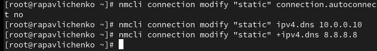

Работа с подключениями

## Изменили IP-адрес статического соединения. Добавили другой IP-адрес для статического соединения. После изменения свойств соединения активировали его. Проверили успешность переключения при помощи nmcli con show и ip addr

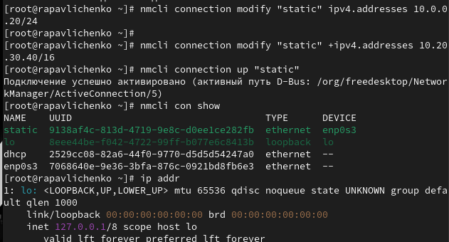

Работа с IP-адресами

## Используя nmtui, посмотрели настройки сети на устройстве.

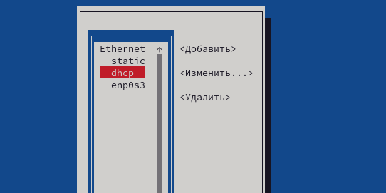

Просмотр настроек сети

## Посмотрели настройки сетевых соединений в графическом интерфейсе операционной системы.

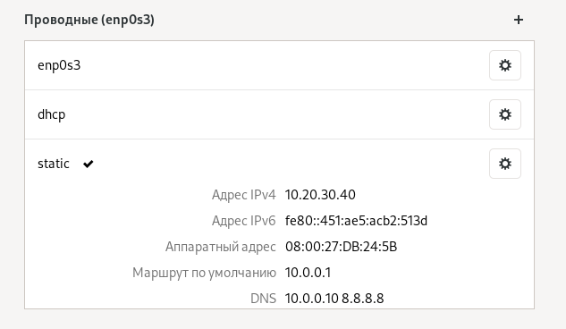

Просмотр настроек сети через графический интерфейс

## Переключились на первоначальное сетевое соединение

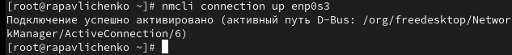

Переключение на первоначальное сетевое соединение